# Meta-analysis physiological costs of hibernation: Report 3 - GC Hibernation

Pablo Capilla-Lasheras

2026-05-04

This [R Markdown](http://rmarkdown.rstudio.com) Notebook contains the initial meta-analysis for the project ‘physiological ’costs’ of hibernation. Specifically, the meta-analysis of hibernation

## Dataset and calculation of effect sizes

The dataset for this meta-analysis has been collected from the literature and curated by Pablo Burraco, Marko Prokic and Tamara Petrovic. It contains data on physiological effects of hibernation in different systems. Here a quick snapshot of the first lines of the dataset:

```r
# dataset with raw data
data <- openxlsx::read.xlsx(
  here(
    "./01_data/raw_data/Burraco_et_al_hibernation_hibernation.xlsx"
  ),
  colNames = T,
  sheet = 3
)

paged_table(data, options = list(rows.print = 20))
```

|  | Reference | Year | StudyID | Species | Thermoregulation | Class | Class_2 | Ver_Invert | Experiment_venue | Tissue | Cortisol_or_corticosterone | Unit | Euthermia_N | Euthermia_M | Euthermia_SD | Euthermia_SE | Hib_N | Hib_M | Hib_SD | Hib_SE | median_euthermia | Q1_euthermia | Q3_euthermia | median_hibernation | Q1_hibernation | Q3_hibernation |
| --- | --- | --- | --- | --- | --- | --- | --- | --- | --- | --- | --- | --- | --- | --- | --- | --- | --- | --- | --- | --- | --- | --- | --- | --- | --- | --- |
| 1 | Bitting et al., 1999 | 1999 | Study1728 | Callospermophilus lateralis | Endotherm | Mammalia | Vertebrate | Vertebrate | Laboratory | Whole-body | Cortisol | ug/dL | 3 | 2.380952 | NA | 0.7407407 | 3 | 4.656085 | NA | 1.164021 | NA | NA | NA | NA | NA | NA |
| 2 | Bitting et al., 1999 | 1999 | Study1728 | Callospermophilus lateralis | Endotherm | Mammalia | Vertebrate | Vertebrate | Laboratory | Whole-body | Cortisol | ug/dL | 3 | 23.756614 | NA | 3.3862434 | 3 | 4.656085 | NA | 1.164021 | NA | NA | NA | NA | NA | NA |
| 3 | Dauphin-Villemant et al., 1990 | 1990 | Study765 | Zootoca vivipara | Ectotherm | Reptilia | NA | Vertebrate | Laboratory | Plasma | Corticosterone | ng/mL | 15 | 25.931034 | NA | 2.9425287 | 5 | 57.380224 | NA | 23.960234 | NA | NA | NA | NA | NA | NA |
| 4 | Dauphin-Villemant et al., 1990 | 1990 | Study765 | Zootoca vivipara | Ectotherm | Reptilia | NA | Vertebrate | Laboratory | Plasma | Corticosterone | ng/mL | 15 | 25.931034 | NA | 2.9425287 | 5 | 50.408159 | NA | 9.082635 | NA | NA | NA | NA | NA | NA |
| 5 | Dauphin-Villemant et al., 1990 | 1990 | Study765 | Zootoca vivipara | Ectotherm | Reptilia | NA | Vertebrate | Laboratory | Plasma | Corticosterone | ng/mL | 15 | 25.931034 | NA | 2.9425287 | 5 | 63.332944 | NA | 17.775081 | NA | NA | NA | NA | NA | NA |
| 6 | Dauphin-Villemant et al., 1990 | 1990 | Study765 | Zootoca vivipara | Ectotherm | Reptilia | NA | Vertebrate | Laboratory | Plasma | Corticosterone | ng/mL | 15 | 25.931034 | NA | 2.9425287 | 5 | 32.125271 | NA | 11.013979 | NA | NA | NA | NA | NA | NA |
| 7 | Dauphin-Villemant et al., 1990 | 1990 | Study765 | Zootoca vivipara | Ectotherm | Reptilia | NA | Vertebrate | Laboratory | Plasma | Corticosterone | ng/mL | 15 | 25.931034 | NA | 2.9425287 | 5 | 19.804439 | NA | 2.707055 | NA | NA | NA | NA | NA | NA |
| 8 | Dauphin-Villemant et al., 1990 | 1990 | Study765 | Zootoca vivipara | Ectotherm | Reptilia | NA | Vertebrate | Laboratory | Plasma | Corticosterone | ng/mL | 15 | 25.931034 | NA | 2.9425287 | 5 | 33.429325 | NA | 7.729108 | NA | NA | NA | NA | NA | NA |
| 9 | Dauphin-Villemant et al., 1990 | 1990 | Study765 | Zootoca vivipara | Ectotherm | Reptilia | NA | Vertebrate | Laboratory | Plasma | Corticosterone | ng/mL | 15 | 25.931034 | NA | 2.9425287 | 5 | 41.195402 | NA | 6.068966 | NA | NA | NA | NA | NA | NA |
| 10 | Dauphin-Villemant et al., 1990 | 1990 | Study765 | Zootoca vivipara | Ectotherm | Reptilia | NA | Vertebrate | Laboratory | Plasma | Corticosterone | ng/mL | 15 | 25.931034 | NA | 2.9425287 | 5 | 62.712644 | NA | 4.965517 | NA | NA | NA | NA | NA | NA |

[output cut: 107 more lines]

As a summary of the *initial dataset*:

- Number of studies: 18
- Number of species: 12

For this initial meta-analysis, I am going to include all glucocorticoid (GC) markers and calculate the standarised mean difference (g; with heteroscedastic population variances) as the effect size of analysis comparing **hibernation** *versus* **euthermia**. Positive SMD values indicate higher GC values in *hibernation* while negative SMD indicate lower GC values in hibernation. This is a summary of the effect size calculation based on the dataset above:

```r
# ES data
data <- readRDS(
  here(
    "./01_data/processed_RDS_data_files/03_GC_metaanalysis_hibernation_full_data.RDS"
  )
)
data$obsID <- 1:nrow(data) # observation ID

data$scientific_name <- gsub(
  x = data$Species,
  pattern = "_",
  replacement = " "
)

data$scientific_name_phylo <- data$scientific_name

## data for SMD
df_SMD <- data %>%
  filter(!is.na(SMDH)) %>%
  filter(!is.na(SMDH.sv))

# matrix with phylogentic correlations
phylo_cor <- readRDS(
  here(
    "./01_data/processed_RDS_data_files/03_GC_phylogenetic_correlations_hibernation.RDS"
  )
)

phylo_tree <- readRDS(
  here(
    "./01_data/processed_RDS_data_files/03_GC_phylogenetic_tree_hibernation.RDS"
  )
)

tree <- ggtree(phylo_tree, size = 1.2) +
  xlim_tree(c(0, 35)) +
  geom_tiplab(
    aes(
      label = paste0(
        "italic('",
        sub(x = label, pattern = "_", replacement = " "),
        "')"
      )
    ),
    parse = TRUE,
    offset = 0.5,
    size = 5,
    hjust = 0
  )

ggsave(
  filename = here(
    "./03_plots/01_hibernation/00c_GC_phylo_tree.png"
  ),
  plot = tree,
  device = "png",
  height = 150,
  width = 90,
  units = "mm"
)

ggsave(
  filename = here(
    "./03_plots/01_hibernation/00c_GC_phylo_tree.pdf"
  ),
  plot = tree,
  height = 150,
  width = 90,
  units = "mm"
)
```

Summary of SMD effect size and number of observations included in the meta-analysis:

```r
summary(df_SMD$SMDH)
```

```
##    Min. 1st Qu.  Median    Mean 3rd Qu.    Max.
## -9.1685 -0.2302  0.7730  0.4834  1.4375  4.8164
```

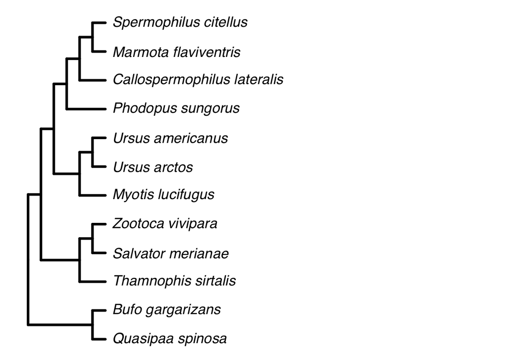

```r
print(tree)
```

- Number of observation with non-missing SMD: 94
- Number of studies in the dataset for analysis: 17
- Number of species in the dataset for analysis: 12

## Initial meta-analysis:

This initial model contains only the intercept and four random effects to account for phylogenetic variation and variation between and within studies beyond sampling variance.

```r
## calculate var-cover matrix to control for correlated effect sizes within study and tissue
V <- vcalc(
  vi = SMDH.sv,
  cluster = StudyID,
  subgroup = Tissue,
  grp1 = Hib_M,
  grp2 = Euthermia_M,
  w1 = Hib_N,
  w2 = Euthermia_N,
  data = df_SMD
)

# model
model_SMD <- rma.mv(
  yi = SMDH,
  V = V,
  mods = ~1,
  random = list(
    ~ 1 | scientific_name_phylo,
    ~ 1 | Species,
    ~ 1 | obsID,
    ~ 1 | StudyID
  ),
  data = df_SMD,
  R = list(scientific_name_phylo = phylo_cor),
  method = "REML",
  control = list(optimizer = "BFGS"),
  verbose = F
)
```

```r
saveRDS(
  object = model_SMD,
  file = here(
    './04_models/01_hibernation/01c_metamodel_hibernation_GC.RDS'
  )
)
model_SMD <- readRDS(
  file = here(
    './04_models/01_hibernation/01c_metamodel_hibernation_GC.RDS'
  )
)
summary(model_SMD)
```

```
##
## Multivariate Meta-Analysis Model (k = 94; method: REML)
##
##    logLik   Deviance        AIC        BIC       AICc
## -146.8289   293.6578   303.6578   316.3208   304.3475
##
## Variance Components:
##
##             estim    sqrt  nlvls  fixed                 factor    R
## sigma^2.1  7.3570  2.7124     12     no  scientific_name_phylo  yes
## sigma^2.2  0.0245  0.1566     12     no                Species   no
## sigma^2.3  0.3918  0.6260     94     no                  obsID   no
## sigma^2.4  0.0785  0.2802     17     no                StudyID   no
##
## Test for Heterogeneity:
## Q(df = 93) = 439.2685, p-val < .0001
##
## Model Results:
##
## estimate      se    zval    pval    ci.lb   ci.ub
##   0.5148  1.5331  0.3358  0.7370  -2.4901  3.5197
##
## ---
## Signif. codes:  0 '***' 0.001 '**' 0.01 '*' 0.05 '.' 0.1 ' ' 1
```

```r
i2_SMD <- round(i2_ml(model_SMD), digits = 4) # heterogeneity random effects
```

Proportion of variation left after accounting for sampling variance and proportion accounted by each random effect:

```r
knitr::kable(
  x = data.frame(
    Variable = names(i2_SMD),
    i2_value_percentage = as.numeric(round(i2_SMD, digits = 3))
  )
) %>%
  kableExtra::kable_styling(full_width = F)
```

| Variable | i2_value_percentage |
| --- | --- |
| I2_Total | 95.927 |
| I2_scientific_name_phylo | 89.881 |
| I2_Species | 0.300 |
| I2_obsID | 4.787 |
| I2_StudyID | 0.959 |

### Plot of results of intercept-only model:

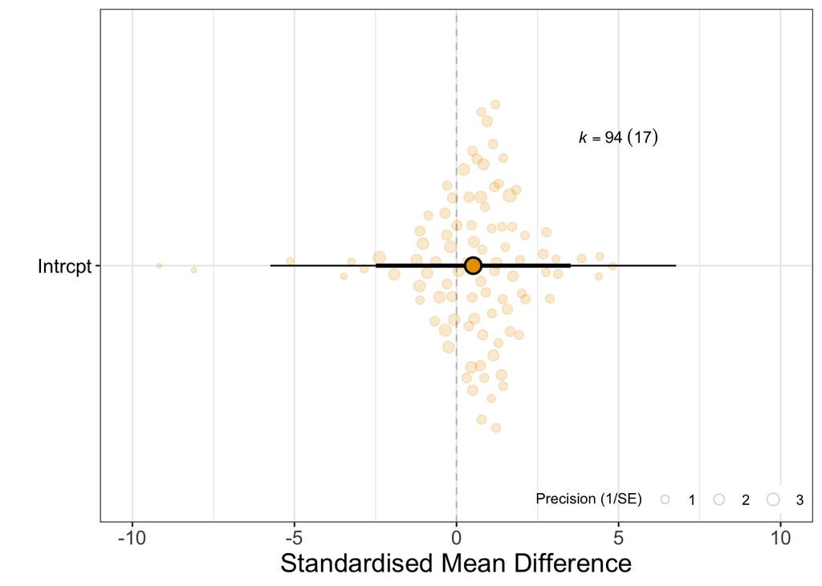

```r
overall_plot <- orchard_plot(
  object = model_SMD,
  mod = "1",
  group = 'StudyID',
  k.pos = 5,
  trunk.size = 1,
  alpha = 0.2,
  cb = FALSE,
  xlab = "Standardised Mean Difference",
  transfm = "none"
) +
  scale_fill_okabe_ito() +
  scale_color_okabe_ito() +
  theme(
    axis.text = element_text(size = 12),
    axis.text.y = element_text(size = 12, angle = 0),
    axis.title = element_text(size = 16)
  ) +
  scale_y_continuous(
    limits = c(-10, 10),
    breaks = seq(-10, 10, 5),
    label = seq(-10, 10, 5)
  )

overall_plot
```

```r
ggsave(
  filename = here(
    "./03_plots/01_hibernation/01c_overall_plot_hibernation_GC.png"
  ),
  plot = overall_plot,
  device = "png",
  height = 110,
  width = 185,
  units = "mm"
)

ggsave(
  filename = here(
    "./03_plots/01_hibernation/01c_overall_plot_hibernation_GC.pdf"
  ),
  plot = overall_plot,
  height = 110,
  width = 185,
  units = "mm"
)
```

### Publication bias: small-study effects

```r
df_SMD$inv_eff_ss <- (1 / df_SMD$Hib_N) + (1 / df_SMD$Euthermia_N)

model_SMD_pb <- rma.mv(
  yi = SMDH,
  V = V,
  mods = ~ 1 + sqrt(inv_eff_ss),
  random = list(
    ~ 1 | scientific_name_phylo,
    ~ 1 | Species,
    ~ 1 | obsID,
    ~ 1 | StudyID
  ),
  data = df_SMD,
  R = list(scientific_name_phylo = phylo_cor),
  method = "REML",
  control = list(optimizer = "BFGS"),
  verbose = F
)
```

```r
saveRDS(
  object = model_SMD_pb,
  file = here(
    './04_models/01_hibernation/06c_pb_metamodel_hibernation_GC.RDS'
  )
)
model_SMD_pb <- readRDS(
  file = here(
    './04_models/01_hibernation/06c_pb_metamodel_hibernation_GC.RDS'
  )
)

summary(model_SMD_pb)
```

```
##
## Multivariate Meta-Analysis Model (k = 94; method: REML)
##
##    logLik   Deviance        AIC        BIC       AICc
## -145.4808   290.9617   302.9617   318.0924   303.9499
##
## Variance Components:
##
##             estim    sqrt  nlvls  fixed                 factor    R
## sigma^2.1  7.2908  2.7001     12     no  scientific_name_phylo  yes
## sigma^2.2  0.0399  0.1997     12     no                Species   no
## sigma^2.3  0.4021  0.6341     94     no                  obsID   no
## sigma^2.4  0.0798  0.2825     17     no                StudyID   no
##
## Test for Residual Heterogeneity:
## QE(df = 92) = 431.7954, p-val < .0001
##
## Test of Moderators (coefficient 2):
## QM(df = 1) = 0.0310, p-val = 0.8603
##
## Model Results:
##
##                   estimate      se    zval    pval    ci.lb   ci.ub
## intrcpt             0.3909  1.6827  0.2323  0.8163  -2.9072  3.6889
## sqrt(inv_eff_ss)    0.2399  1.3632  0.1760  0.8603  -2.4319  2.9118
##
## ---
## Signif. codes:  0 '***' 0.001 '**' 0.01 '*' 0.05 '.' 0.1 ' ' 1
```

### Publication bias: time-lag effects

```r
df_SMD$year_scl <- scale(df_SMD$Year)

model_SMD_tl <- rma.mv(
  yi = SMDH,
  V = V,
  mods = ~ 1 + year_scl,
  random = list(
    ~ 1 | scientific_name_phylo,
    ~ 1 | Species,
    ~ 1 | obsID,
    ~ 1 | StudyID
  ),
  data = df_SMD,
  R = list(scientific_name_phylo = phylo_cor),
  method = "REML",
  control = list(optimizer = "BFGS"),
  verbose = F
)
```

```r
saveRDS(
  object = model_SMD_tl,
  file = here(
    './04_models/01_hibernation/07c_timelag_metamodel_hibernation_GC.RDS'
  )
)
model_SMD_tl <- readRDS(
  file = here(
    './04_models/01_hibernation/07c_timelag_metamodel_hibernation_GC.RDS'
  )
)

summary(model_SMD_tl)
```

```
##
## Multivariate Meta-Analysis Model (k = 94; method: REML)
##
##    logLik   Deviance        AIC        BIC       AICc
## -144.8428   289.6856   301.6856   316.8164   302.6739
##
## Variance Components:
##
##             estim    sqrt  nlvls  fixed                 factor    R
## sigma^2.1  7.4800  2.7350     12     no  scientific_name_phylo  yes
## sigma^2.2  0.0062  0.0787     12     no                Species   no
## sigma^2.3  0.3941  0.6278     94     no                  obsID   no
## sigma^2.4  0.1090  0.3301     17     no                StudyID   no
##
## Test for Residual Heterogeneity:
## QE(df = 92) = 410.3641, p-val < .0001
##
## Test of Moderators (coefficient 2):
## QM(df = 1) = 0.0736, p-val = 0.7862
##
## Model Results:
##
##           estimate      se    zval    pval    ci.lb   ci.ub
## intrcpt     0.5037  1.5464  0.3257  0.7446  -2.5272  3.5345
## year_scl    0.0798  0.2940  0.2713  0.7862  -0.4966  0.6561
##
## ---
## Signif. codes:  0 '***' 0.001 '**' 0.01 '*' 0.05 '.' 0.1 ' ' 1
```

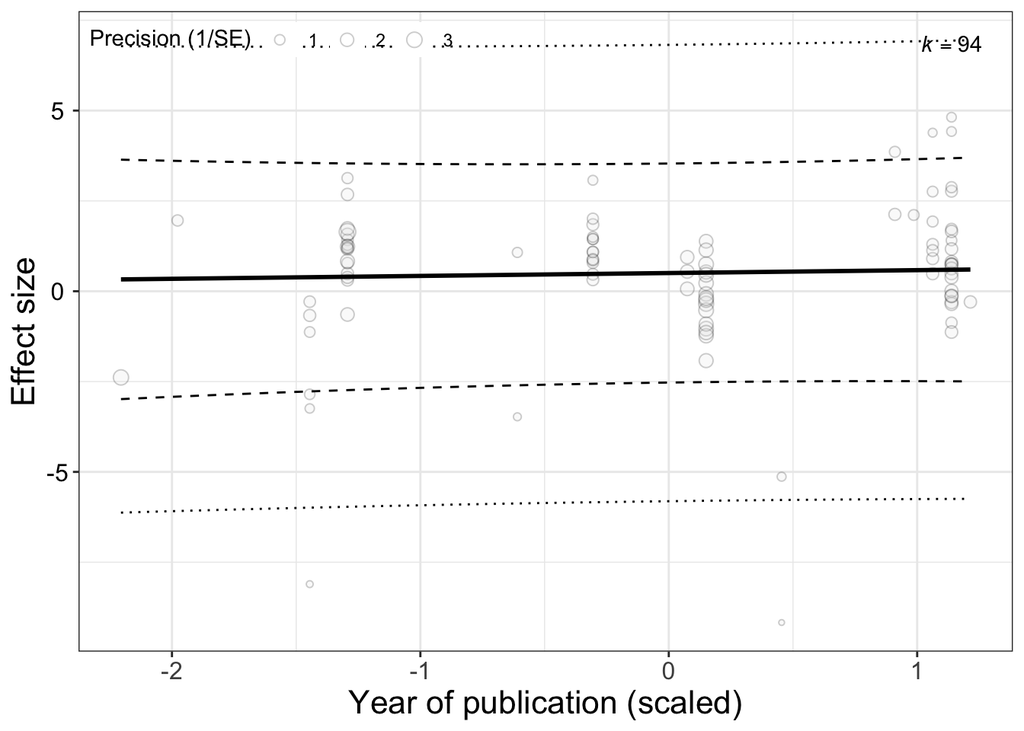

```r
results <- mod_results(model_SMD_tl, mod = "year_scl", group = "StudyID")
orchaRd::bubble_plot(
  model_SMD_tl,
  mod = 'year_scl',
  group = 'StudyID',
  alpha = 0.2,
  cb = FALSE,
  xlab = "Year of publication (scaled)",
  transfm = "none",
) +
  theme(
    axis.text = element_text(size = 12),
    axis.text.y = element_text(size = 12, angle = 0),
    axis.title = element_text(size = 16)
  )
```

## Meta-analysis including thermoregulation type as a moderator:

Number of observations for each type:

```r
table(df_SMD$Thermoregulation)
```

```
##
## Ectotherm Endotherm
##        63        31
```

```r
model_SMD_thermoregulation <- rma.mv(
  yi = SMDH,
  V = V,
  mods = ~ Thermoregulation - 1,
  random = list(
    ~ 1 | scientific_name_phylo,
    ~ 1 | Species,
    ~ 1 | obsID,
    ~ 1 | StudyID
  ),
  data = df_SMD,
  R = list(scientific_name_phylo = phylo_cor),
  method = "REML",
  control = list(optimizer = "BFGS"),
  verbose = F
)
```

```r
saveRDS(
  object = model_SMD_thermoregulation,
  file = here(
    './04_models/01_hibernation/03c_metareg_thermoregulation_hibernation_GC.RDS'
  )
)
model_SMD_thermoregulation <- readRDS(
  file = here(
    './04_models/01_hibernation/03c_metareg_thermoregulation_hibernation_GC.RDS'
  )
)
summary(model_SMD_thermoregulation)
```

```
##
## Multivariate Meta-Analysis Model (k = 94; method: REML)
##
##    logLik   Deviance        AIC        BIC       AICc
## -143.2418   286.4835   298.4835   313.6143   299.4718
##
## Variance Components:
##
##             estim    sqrt  nlvls  fixed                 factor    R
## sigma^2.1  8.7488  2.9578     12     no  scientific_name_phylo  yes
## sigma^2.2  0.0009  0.0297     12     no                Species   no
## sigma^2.3  0.3917  0.6259     94     no                  obsID   no
## sigma^2.4  0.0732  0.2705     17     no                StudyID   no
##
## Test for Residual Heterogeneity:
## QE(df = 92) = 423.8564, p-val < .0001
##
## Test of Moderators (coefficients 1:2):
## QM(df = 2) = 0.3542, p-val = 0.8377
##
## Model Results:
##
##                            estimate      se     zval    pval    ci.lb   ci.ub
## ThermoregulationEctotherm    1.0907  2.0209   0.5397  0.5894  -2.8702  5.0515
## ThermoregulationEndotherm   -0.3735  2.3986  -0.1557  0.8763  -5.0747  4.3278
##
## ThermoregulationEctotherm
## ThermoregulationEndotherm
##
## ---
## Signif. codes:  0 '***' 0.001 '**' 0.01 '*' 0.05 '.' 0.1 ' ' 1
```

### Plot of results of thermoregulation meta-regression:

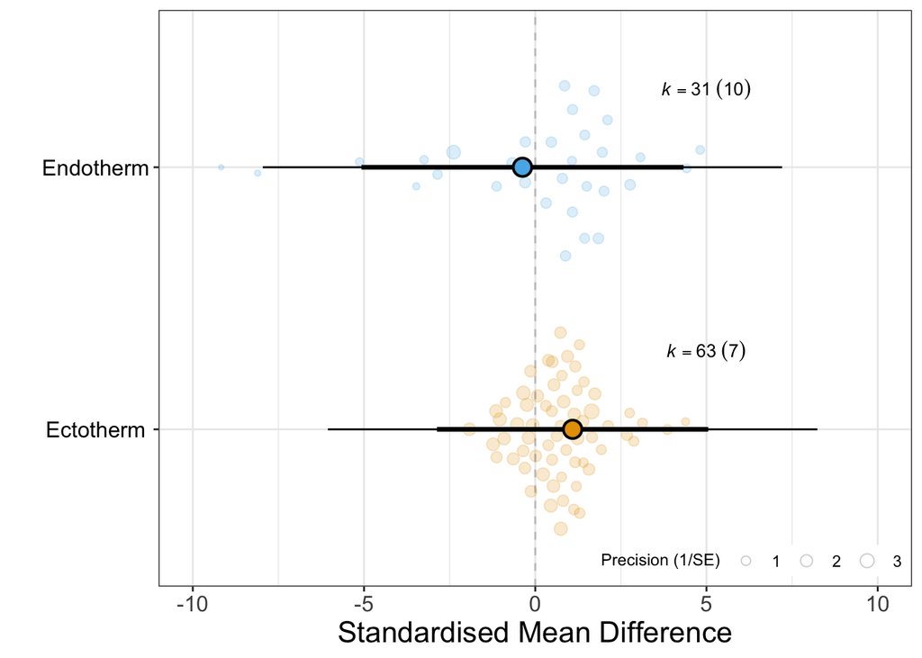

```r
thermo_plot <- orchard_plot(
  object = model_SMD_thermoregulation,
  mod = 'Thermoregulation',
  group = 'StudyID',
  k.pos = 5,
  trunk.size = 1,
  alpha = 0.2,
  cb = FALSE,
  xlab = "Standardised Mean Difference",
  transfm = "none"
) +
  scale_fill_okabe_ito() +
  scale_color_okabe_ito() +
  theme(
    axis.text = element_text(size = 12),
    axis.text.y = element_text(size = 12, angle = 0),
    axis.title = element_text(size = 16)
  ) +
  scale_y_continuous(
    limits = c(-10, 10),
    breaks = seq(-10, 10, 5),
    label = seq(-10, 10, 5)
  )

thermo_plot
```

```r
ggsave(
  filename = here(
    "./03_plots/01_hibernation/03c_thermoregulation_plot_GC.png"
  ),
  plot = thermo_plot,
  device = "png",
  height = 120,
  width = 185,
  units = "mm"
)

ggsave(
  filename = here(
    "./03_plots/01_hibernation/03c_thermoregulation_plot_GC.pdf"
  ),
  plot = thermo_plot,
  height = 120,
  width = 185,
  units = "mm"
)
```